# FinRisk – June 2025 Update

Lucas da C. Godoy

ldcgodoy@ucsc.com

EEB Department, UCSC

Mark Morales

mamamora@ucsc.com

EEB Department, UCSC

Malin Pinsky

mpinsky@ucsc.com

EEB Department, UCSC

2025-06-23

## Overview

- `drmr` package: got authors approval to submit the current version of the paper. Package documentation available [here](https://pinskylab.github.io/drmr/).
- In the last meeting, we briefly talked about data availability and key environmental drivers to study Mackerel’s distribution.
- A lot of time spent looking for the data and processing it.
- The data from the survey we identified as the most approprate is “sparsely available”.

| Survey | Distribution | Start | Age structure |
| --- | --- | --- | --- |
| **IESSNS** | Summer feeding | 2010 | Age and size composition (Age 3+) |
| BTS | Overwinter | 1965 | Age-0 abundance index |
| Egg Survey | Spawning | 1992 | No age structure |

## IESSNS data

- Previous papers using IESSNS data [e.g.; Ono et al. (2024)] mention the data is available from the *Planning Group on Northeast Atlantic Pelagic Ecosystem Surveys (PGNAPES)*
- I could not find that data on the ICES portal.
- I connectect with Anna Heiða Ólafsdóttir, she pointed that the PGNAPES data is not publicly available. Some of it is available through a hard to find ICES portal.

## Data processing

| V1 | V2 | V3 | V4 | V5 | V6 | V7 | V8 | V9 | V10 | V11 | V12 | V13 | V14 | V15 | V16 | V17 | V18 | V19 | V20 | V21 | V22 | V23 | V24 | V25 | V26 | V27 | V28 | V29 | V30 | … |
| --- | --- | --- | --- | --- | --- | --- | --- | --- | --- | --- | --- | --- | --- | --- | --- | --- | --- | --- | --- | --- | --- | --- | --- | --- | --- | --- | --- | --- | --- | --- |
| Cruise | Header | CruiseSurvey | CruiseCountry | CruisePlatform | CruiseStartDate | CruiseEndDate | CruiseOrganisation | CruiseLocalID |  |  |  |  |  |  |  |  |  |  |  |  |  |  |  |  |  |  |  |  |  | … |
| Cruise | Record | IESSNS | DK | 26AS | 2018-07-02 | 2018-07-13 | 2195 | IESSNS_DK_2018 |  |  |  |  |  |  |  |  |  |  |  |  |  |  |  |  |  |  |  |  |  | … |
| Haul | Header | CruiseLocalID | HaulGear | HaulNumber | HaulStationName | HaulStartTime | HaulDuration | HaulValidity | HaulStartLatitude | HaulStartLongitude | HaulStopLatitude | HaulStopLongitude | HaulStatisticalRectangle | HaulMinTrawlDepth | HaulMaxTrawlDepth | HaulBottomDepth | HaulDistance | HaulNetopening | HaulCodendMesh | HaulSweepLength | HaulGearExceptions | HaulDoorType | HaulWarpLength | HaulWarpDiameter | HaulWarpDensity | HaulDoorSurface | HaulDoorWeight | HaulDoorSpread | HaulWingSpread | … |
| Haul | Record | IESSNS_DK_2018 | PEL | 1 | 1 | 2018-07-02T20:20 | 30 | V | 57.882168 | 9.613833 | 57.905666 | 9.561 | 44F9 | 0 |  | 102 | 4471 | 28 | 20 |  |  |  |  |  |  |  |  | 122 |  | … |
| Haul | Record | IESSNS_DK_2018 | PEL | 2 | 2 | 2018-07-03T04:25 | 30 | V | 57.835 | 8.143167 | 57.846 | 8.072333 | 44F8 | 0 |  | 525 | 4683 | 32 | 20 |  |  |  |  |  |  |  |  | 121 |  | … |
| Haul | Record | IESSNS_DK_2018 | PEL | 3 | 3 | 2018-07-03T09:26 | 30 | V | 57.896 | 6.6373334 | 57.936333 | 6.6435 | 44F6 | 0 |  | 368 | 4709 | 35 | 20 |  |  |  |  |  |  |  |  | 121 |  | … |

## Hauls

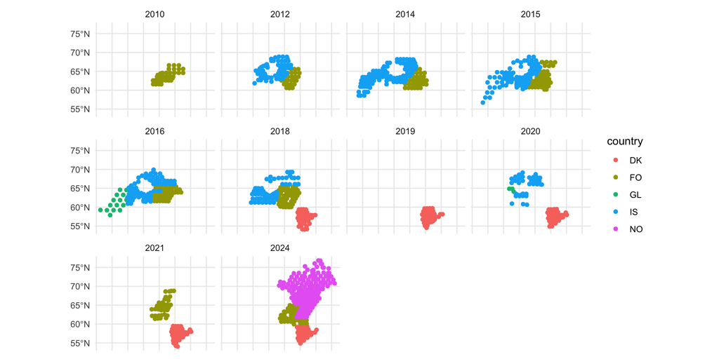

## Hauls 2024

[interactive chart not shown]

## Incorporating BT

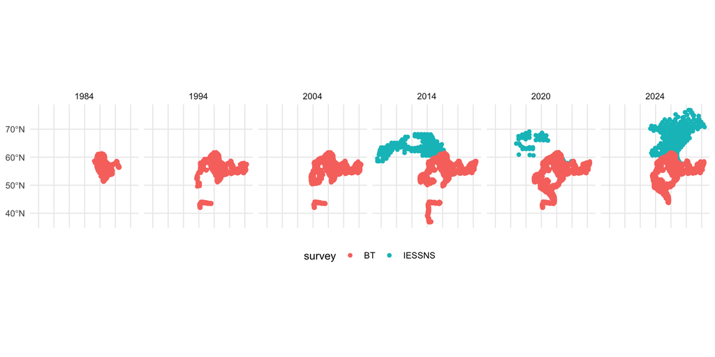

## ICES “rectangles”

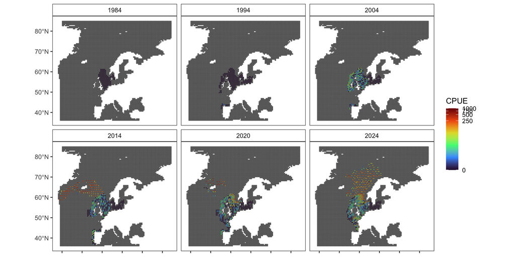

## CPUE (across all surveys) over time

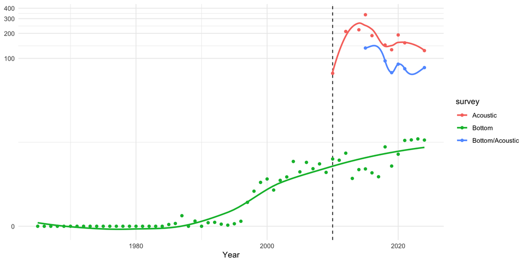

## Next Steps & Questions

- More data processing :(
- Although the spatiotemporal coverage we have is challenging, these are the circumstanes where model-based approaches (e.g., DRM) “shine”
- For the models, I need to be careful and think about how to incorporate the information from the different surveys (suggestions welcome)
- What spatial resolution would be best for the translational tools and economical risk part of the project?
- Is the main goal to quantify range shifts or are we aiming at forecasting abundance / Biomass?

### References

Ono, K., Katara, I., Eliasen, S. K., Broms, C., Campbell, A., Santos Schmidt, T. C. dos, Egan, A., Hølleland, S. N., Jacobsen, J. A., Jansen, T., Mackinson, S., Mousing, E. A., Nash, R. D. M., Nikolioudakis, N., Nnanatu, C., Nøttestad, L., Singh, W., Slotte, A., Wieland, K., and Olafsdottir, A. H. (2024), “Effect of environmental drivers on the spatiotemporal distribution of mackerel at age in the Nordic Seas during 2010-20,” *ICES Journal of Marine Science*, 81, 1282–1294. https://doi.org/10.1093/icesjms/fsae087.